# Tarifa Zero no Brasil

Aline Maria e João Lucas

2024-09-06

# Resumo

# 1 Introdução

No Brasil, o sistema de transporte coletivo urbano é um serviço público, sendo comumente operado por empresas privadas a partir de concessões ou permissões, municipais ou distritais (Schiaffino; Toledo; Ribeiro, 2015). Dessa forma, apesar do governo gerir esse serviço, o seu funcionamento está suscetível às demandas e interesses de grandes empresários do transporte, inserindo no custo do serviço uma margem para garantir a lucratividade. Nesse cenário, o valor das tarifas a ser pago pelo próprio usuário tende a ser, muitas vezes, insustentável para uma parcela significativa das pessoas que dependem desse serviço para se locomover (de Carvalho, 2011).

A implementação da Tarifa Zero universal nos transportes coletivos tem sido proposta como uma possível solução para a promoção do direito à cidade, como uma forma de mitigar as desigualdades características do contexto urbano capitalista. Partidos, ativistas, movimentos sociais e pesquisadores do tema reivindicam a luta pela Tarifa Zero enquanto política de promoção não só do direito à cidade, mas também de alternativas ecológicas e mais saudáveis de funcionamento da mobilidade urbana em geral.

Hoje, estima-se que mais de 110 cidades adotam essa política no Brasil, e a discussão sobre as condições para a sua implementação tem ganhado destaque no debate público.

## 1.1 Objetivos

Essa pesquisa tem como objetivo geral estabelecer um panorama sobre a difusão da implementação da Tarifa Zero nos sistemas de transporte público dos municípios brasileiros. Além disso, também serão analisadas a correlação entre as variáveis Competição Política e PIB per capita com a adoção dessa política.

Nesse sentido, testamos as seguintes hipóteses:

- Municípios com alta competitividade política (relacionado às eleições do executivo municipal) estão mais propensos à adoção devido à pressão para se diferenciar dos outros candidatos.
- Municípios com alto PIB per capita estão mais propensos à adoção, pois essa medida é utilizada como um proxy de desenvolvimento econômico do município.

## 1.2 Justificativa

É evidente a relevância do transporte público no funcionamento das cidades e na vida de seus habitantes, sendo um serviço essencial para a garantia de uma cidadania plena à medida que o acesso à mobilidade urbana interfere no acesso a outros direitos e serviços. Nesse sentido, impossibilitar a utilização do serviço de transporte público por meio da cobrança de tarifas diretas incompatíveis com a renda de determinados grupos sociais significa reproduzir segregações socioespaciais e intensificar as distintas formas de desigualdade que perpassam o contexto urbano.

Isso posto, é de grande relevância estabelecer um panorama que analise o histórico de implementação dessa política e que entenda se determinadas características (competição política e PIB per capita) são relevantes nesse processo.

# 2 Método

Para a realização desse trabalho, foram utilizados os dados compilados por Daniel Santini (2024), referentes aos municípios que adotam a Tarifa Zero universal no Brasil. Além disso, também foi utilizada uma base de dados fornecida por Denilson Bandeira Coêlho (2016), a qual contém dados sobre variáveis específicas de 5.564 municípios brasileiros. Importante destacar que esses dados não estão atualizados, tendo como limite o ano de publicação do artigo do autor citado.

Foi realizada uma mescla das duas bases de dados e o dataset foi adaptado para essa política em questão, excluindo variáveis que não seriam interessantes e incluindo novas. Primeiramente, realizamos uma análise estatística descritiva desses dados, com o intuito de estabelecer um panorama sobre a evolução da adoção da Tarifa Zero nos municípios brasileiras, o porte desses municípios e a sua distribuição no território brasileiro (tendo como base seus estados). Posteriormente, para a testagem das hipóteses sobre a relevância das variáveis de competição política e de PIB per capita, utilizamos a regressão logística por meio do R, com o intuito de medir possíveis correlações com a variável dependente (adoção ou não da Tarifa Zero). Nesse processo, foram analisados apenas os dados de municípios com uma população entre 20 mil e 100 mil habitantes (totalizando 1370 municípios), em um esforço de tornar o modelo mais equilibrado e, também, viabilizar o processamento dos dados.

# 3 Análise

### 3.1 Linha do tempo

É notório o aumento no número de adoções da Tarifa Zero no Brasil, especialmente após a pandemia de COVID-19 em 2020.

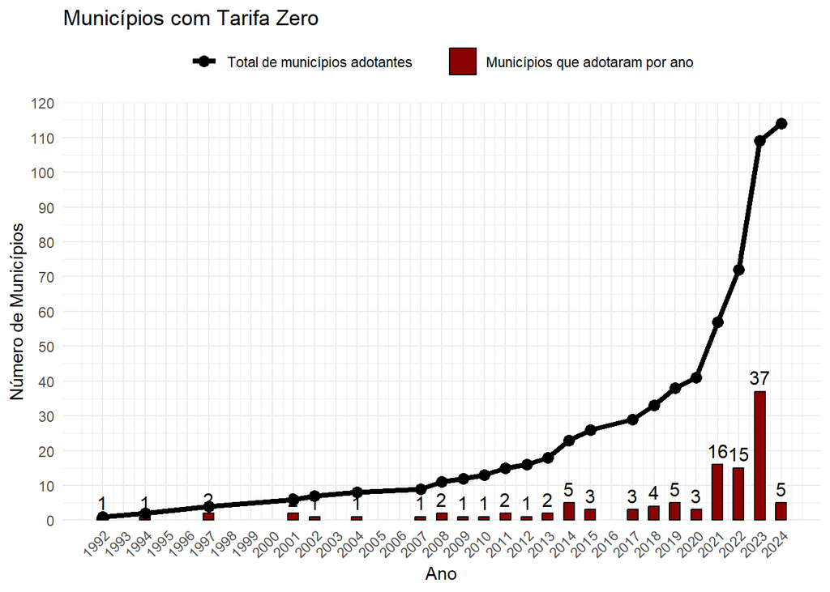

### 3.2 Distribuição geográfica

Percebemos uma alta concentração nos estados do sudeste brasileiro.

| Estado | Sigla | Número de Municípios Adotantes |
| --- | --- | --- |
| São Paulo | SP | 37 |
| Minas Gerais | MG | 27 |
| Paraná | PR | 14 |
| Rio de Janeiro | RJ | 13 |
| Santa Catarina | SC | 7 |
| Goiás | GO | 5 |
| Rio Grande do Sul | RS | 4 |
| Ceará | CE | 3 |
| Bahia | BA | 1 |
| Espírito Santo | ES | 1 |
| Mato Grosso do Sul | MS | 1 |
| Rondônia | RO | 1 |

### 3.3 Municípios por porte

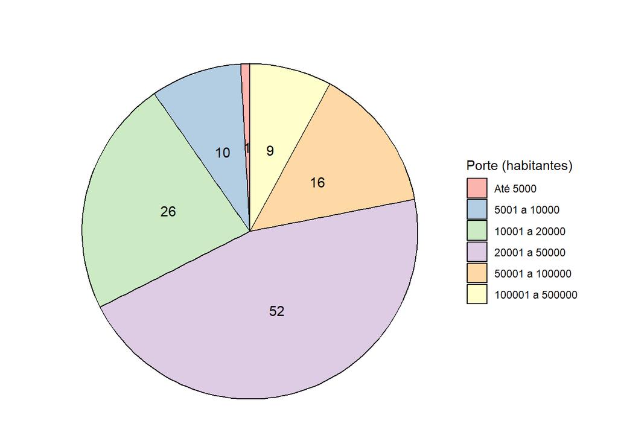

Vemos que a grande maioria os municípios adotantes se enquadram na categoria de pequeno porte (até 100 mil habitantes).

### 3.4 Influência da Competição Política e do PIB per capita

```
## Analysis of Deviance Table (Type II tests)
##
## Response: adotatz
##                    Df  Chisq Pr(>Chisq)
## CompetiçãoPolítica  1 0.2627   0.608239
## PIBpercapitaMedia   1 6.9388   0.008435 **
## ---
## Signif. codes:  0 '***' 0.001 '**' 0.01 '*' 0.05 '.' 0.1 ' ' 1
```

- CompetiçãoPolítica: Não parece ter um efeito significativo na adoção da Tarifa Zero.
- PIBpercapitaMedia: Tem um efeito significativo na adoção da Tarifa Zero (p = 0.00843). O coeficiente negativo sugere que, à medida que o PIB per capita médio aumenta, a probabilidade de adoção da Tarifa Zero diminui. Ou seja, municípios com PIB per capita mais alto são menos propensos a adotar a Tarifa Zero.

Razões de chance

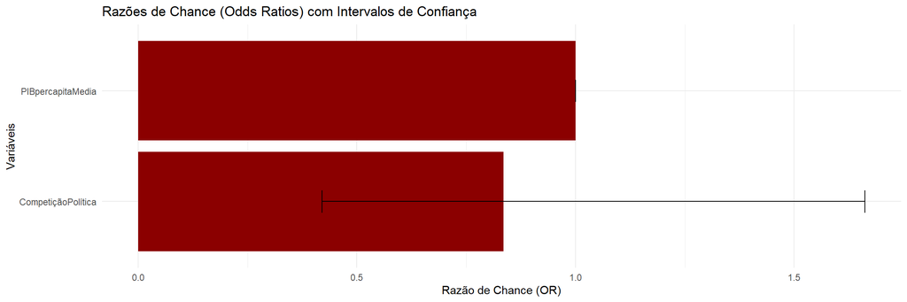

- CompetiçãoPolítica: Um OR de 0.84 significa que, para cada aumento unitário na CompetiçãoPolítica, as chances de adoção da Tarifa Zero diminuem em cerca de 16% (1 - 0.84). Como o intervalo de confiança inclui 1, não podemos afirmar com certeza que a CompetiçãoPolítica tem um efeito estatisticamente significativo sobre a adoção.
- PIBpercapitaMedia: O OR de 0.99998 sugere que um aumento no PIB per capita está associado a uma ligeira diminuição nas chances de adoção da Tarifa Zero. No entanto, o efeito é muito pequeno e o inteorvalo de confiança também é muito estreito, indicando baixa variação.

# 4 Considerações finais

Com base na análise realizada, observamos que a adoção da Tarifa Zero, apesar de se iniciar em 1992, só começou a realmente se popularizar após a pandemia de COVID-19. Acredita-se que a redução da circulação de pessoas nas cidades intensificou o processo de crise no financiamento do transporte público que já ocorria anteriormente. Além disso, também identificamos o perfil dos municípios adotantes a partir do seu porte populacional (majoritariamente municípios de pequeno porte) e, também, a partir de sua Unidade Federativa (São Paulo em primeiro, seguido de Minas Gerais e do Paraná). Destacamos a alta concentração nos estados do sudeste. Nesse cenário, abre-se caminhos para investigações futuras sobre as possíveis motivações dessa configuração atual, de maneira a identificar o que determina ou influencia na formação desses padrões. Já sobre a influência das variáveis de competição política e de PIB per capita, identificou-se que a primeira não é estatisticamente relevante na adoção da Tarifa Zero. Já a segunda é estatisticamente relevante, mas seu efeito é tão marginal que pode ser questionada a sua real importância nesse processo. Além disso, a análise indeicou que a sua relação com a adoção é contrária à nossa hipótese inicial, ou seja, quanto maior o PIB per capita menor a chance de se implementar essa política. No entanto, vale destacar que nesse estudo foram utilizados dados não atualizados e, também, foi realizado um recorte a fim de equilibrar o modelo de regressão e de auxiliar no processamento dos dados. Portanto, é necessário que se realizem pesquisas com dados atualizados e a partir de outros recortes, no intuito de se construir uma análise mais robusta e completa sobre esse tema.

# Referências

- COÊLHO, Denilson Bandeira; CAVALCANTE, Pedro; TURGEON, Mathieu. Mecanismos de difusão de políticas sociais no Brasil: uma análise do Programa Saúde da Família. Revista de Sociologia e Política, v. 24, p. 145-165, 2016.
- DE CARVALHO, Carlos Henrique Ribeiro; PEREIRA, Rafael Henrique Moraes. Efeitos da variação da tarifa e da renda da população sobre a demanda de transporte público coletivo urbano no Brasil. Texto para Discussão, 2011.
- SANTARÉM, Paíque Duques. Ensaio sobre o incontornável: do ciclo vicioso da tarifa ao ciclo virtuoso da Tarifa Zero. Journal of Sustainable Urban Mobility, v. 3, n. 1, p. 21-32, 2023.
- SANTINI, Daniel. Passe livre: as possibilidades da tarifa zero contra a distopia da uberização. Autonomia Literária, 2019.
- Santini, Daniel, 2024, “Brazilian municipalities with full Fare-Free Public Transport policies - updated March 2024”, https://doi.org/10.7910/DVN/Z927PD, Harvard Dataverse, V1
- SCHIAFFINO, Daniela Ponce de Leon; TOLEDO, Juliana Iara de Freitas; RIBEIRO, Renato Guimarães. Tarifa Zero: uma reflexão sobre a proposta. CEFET-MG, 2015. Disponível em: http://files-server.antp.org.br/_5dotSystem/download/dcmDocument/2015/06/15/C088AE 18-A9D3-4CCD-9A56-F54E04438370.pdf. Acesso em 06/09/2023.